# Coursera Reproducible Research: Final Assignment

Ritayan B

25 February 2016

# Some meta Information

Data downloaded on - 26-February-2016

The file was downloaded from the location https://d396qusza40orc.cloudfront.net/repdata%2Fdata%2FStormData.csv.bz2

National Weather Service Storm Data Documentation https://d396qusza40orc.cloudfront.net/repdata%2Fpeer2_doc%2Fpd01016005curr.pdf National Climatic Data Center Storm Events FAQ https://d396qusza40orc.cloudfront.net/repdata%2Fpeer2_doc%2FNCDC%20Storm%20Events-FAQ%20Page.pdf

Setting the initial parameters to setting the working directory, download the file, and store in the working directory

```r
wdir <- "D:/Cloud Storage/Google Drive/Coursera/03. Data Science/05. Reproducible Research/CourseraReproducibleResearch"
url <- "https://d396qusza40orc.cloudfront.net/repdata%2Fdata%2FStormData.csv.bz2"

data.file <- paste(wdir, "/data.csv.bz2", sep = "")
#download.file(url = url, destfile = data.file)
setwd(wdir)
data.storm <- read.csv(bzfile(data.file))
event.count <- 5
```

## Question 1: Across the United States, which types of events (as indicated in the EVTYPE variable) are most harmful with respect to population health?

Using the package dplyr, we are summarizing the data. The data are grouped by event type (EVTYPE). Both fatatalities(FATALITIES) and injuries(INJURIES) are summed up. As we understand, both these types of data contribute towards the population health.

```r
library(dplyr)
```

```r
library(ggplot2)
data.health <- data.storm %>% group_by(EVTYPE) %>% summarise(ALL.FATALITIES = sum(FATALITIES), ALL.INJURIES = sum(INJURIES)) %>% arrange(desc(ALL.FATALITIES+ALL.INJURIES))
```

Picking the top event types for which the casualities are maximum; number determined by the summation of fatalities and injuries The data are tranformed so that couple of facets are created, one for fatalities and another for injuries. The plot is created using ggplot2 package.

```r
data.show <- data.health[1:event.count, ]
a <- data.frame(data.show$ALL.FATALITIES, data.show$EVTYPE, "Fatalities")
b <- data.frame(data.show$ALL.INJURIES, data.show$EVTYPE, "Injuries")
names(a) <- c("Count", "EventType", "ImpactType")
names(b) <- c("Count", "EventType", "ImpactType")
data.plot1 <- rbind(a, b)
```

Data transformation is done. Now plot is created to show the data.

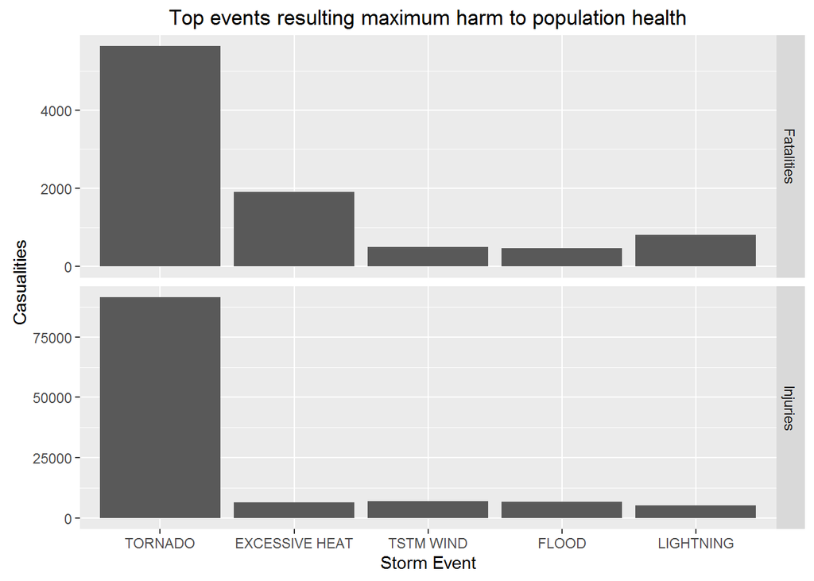

```r
g <- ggplot(data = data.plot1, mapping = aes(x = factor(EventType, levels = EventType), y = Count))
g <- g + geom_bar(stat = "identity") + facet_grid(ImpactType~.,  scale="free")
g <- g + ggtitle("Top events resulting maximum harm to population health")
g <- g + labs(x = "Storm Event", y = "Casualities")
g
```

## Question 2: Across the United States, which types of events have the greatest economic consequences?

We are writing a function to calclate the dollar value of the crop or property damage. This will calculate the number figure based on the expression (PROPDMGEXP/ CROPDMGEXP).

```r
data.ecoloss <- data.storm[data.storm$PROPDMG > 0 & data.storm$CROPDMG > 0, ]

caclculateVal <- function(value, symbol){
  multiplr <- 1
  if(toupper(symbol) == "K"){
    multiplr <- 10^3;
  }else if(toupper(symbol) == "M"){
    multiplr <- 10^6;
  }else if(toupper(symbol) == "B"){
    multiplr <- 10^9;
  }
  value * multiplr;
}
```

```r
data.ecoloss <- data.storm[data.storm$PROPDMG > 0 & data.storm$CROPDMG > 0, ]
data.ecoloss <- mutate(data.ecoloss, PORPLOSS = caclculateVal(data.ecoloss$PROPDMG, data.ecoloss$PROPDMGEXP),                                      CROPLOSS = caclculateVal(data.ecoloss$CROPDMG, data.ecoloss$CROPDMGEXP))
data.ecoloss <- group_by(data.ecoloss, EVTYPE)
data.ecoloss <- summarise(data.ecoloss, ALL.PORPLOSS = sum(PORPLOSS), ALL.CROPLOSS = sum(CROPLOSS))
data.ecoloss <- arrange(data.ecoloss, desc(ALL.PORPLOSS + ALL.CROPLOSS))
```

```r
data.show <- data.ecoloss[1:event.count, ]
a <- data.frame(data.show$ALL.PORPLOSS, data.show$EVTYPE, "Property Loss")
b <- data.frame(data.show$ALL.CROPLOSS, data.show$EVTYPE, "Crop Loss")
names(a) <- c("Loss", "EventType", "LossType")
names(b) <- c("Loss", "EventType", "LossType")
data.plot2 <- rbind(a, b)
```

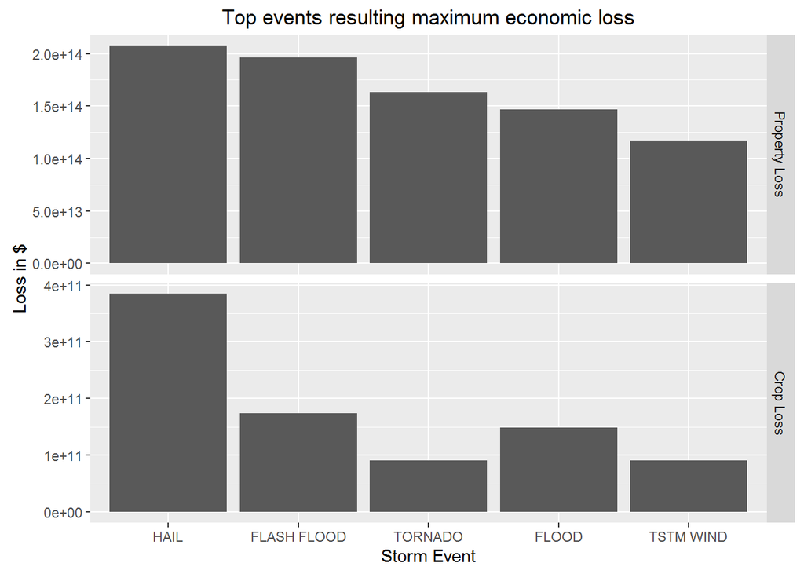

```r
g <- ggplot(data = data.plot2, mapping = aes(x = factor(EventType, levels = EventType), y = Loss))
g <- g + geom_bar(stat = "identity") + facet_grid(LossType~.,  scale="free")
g <- g + ggtitle("Top events resulting maximum economic loss")
g <- g + labs(x = "Storm Event", y = "Loss in $")
g
```